# Genetic Dependency Detection

Martin Brand

April 6, 2023

We import the libraries.

```r
library(tidyverse)
library(ggplot2)
library(ggrepel)
library(matrixTests)
library(dplyr)
library(cowplot)
library(limma)
library(gridExtra)
```

# Analyzed Genes and Target

We define the genes for classification, the expected target gene and the classification criteria.

```r
gene1 <- "KRAS"
gene2 <- "NRAS"
# target.genes <- c("FUBP1","SF1","U2AF1","U2AF2","SNRPB","SNRPD1","SNRPD2",
#                   "SNRPD3","SNRPE","SNRPF","SNRPG","PUF60","SMNDC1",
#                   "DNAJC8","RBM17","CHERP","U2SURP","DHX15","DDX46","CELF6",
#                   "PCBP1")
# target.genes <- c("PARP1","PARP2")
target.genes <- c("NRAS","KRAS")
# possible methods: "del.vs.non.del", "del.vs.non.mut","mut.vs.non.mut"
classification.method <- "mut.vs.non.mut"
```

In this analysis, the genes used for classification are KRAS and NRAS. The expected target gene is NRAS, KRAS.

# Data Preprocessing

We define the directory for the data and helper functions.

```r
data.dir <-
  "C:/Users/Martin/Documents/Master/Thesis/genetic_dependency_detection/data/"
```

We load the dataset that contains CCLE IDs and corresponding DepMap IDs for the cell lines ([DepMapIDs](https://depmap.org/portal/download/all/?releasename=DepMap+Public+18Q3&filename=DepMap-2018q3-celllines.csv)), the dataset that contains the mutation information of the cell lines ([CCLE dataset](https://depmap.org/portal/download/all/?releasename=DepMap+Public+19Q2&filename=CCLE_mutations.csv)) and the datasets that contains the dependency scores from the projects Achilles and DRIVE ([DepMap datasets](https://figshare.com/articles/dataset/DepMap_Datasets_for_WRN_manuscript/7712756/1)).

```r
cancer.names <- read.csv(paste0(data.dir, "DepMap-2018q3-celllines.csv"))
cancer.names <- cancer.names[,c(1,2)]
colnames(cancer.names) <- c("DepMap_ID","CCLE_ID")

CCLE.mut <- read.csv(paste0(data.dir, "CCLE_mutations.csv"))
CCLE.mut <- CCLE.mut[,c(1,8,16,20)]

dep.scores <- read_rds(file.path(data.dir, 'DepMap_18Q4_data.rds'))

dep.scores.DRIVE <- as.data.frame(dep.scores[["DRIVE"]])
dep.scores.DRIVE$CCLE_ID <- rownames(dep.scores.DRIVE)
rownames(dep.scores.DRIVE) <- NULL
dep.scores.DRIVE <- dep.scores.DRIVE %>% select(CCLE_ID, everything())

dep.scores.Achilles <- as.data.frame(dep.scores[["CRISPR"]])
dep.scores.Achilles$CCLE_ID <- rownames(dep.scores.Achilles)
rownames(dep.scores.Achilles) <- NULL
dep.scores.Achilles <- dep.scores.Achilles %>% select(CCLE_ID,everything())

# remove unnecessary objects
rm(dep.scores)

# save important objects
saveRDS(cancer.names,paste0(data.dir,"cancer.names.rds"))
saveRDS(CCLE.mut,paste0(data.dir,"CCLE.mut.rds"))
saveRDS(dep.scores.DRIVE,paste0(data.dir,"dep.scores.DRIVE.rds"))
saveRDS(dep.scores.Achilles,paste0(data.dir,"dep.scores.Achilles.rds"))
```

```r
# load important objects
cancer.names <- readRDS(paste0(data.dir,"cancer.names.rds"))
CCLE.mut <- readRDS(paste0(data.dir,"CCLE.mut.rds"))
dep.scores.DRIVE <- readRDS(paste0(data.dir,"dep.scores.DRIVE.rds"))
dep.scores.Achilles <- readRDS(paste0(data.dir,"dep.scores.Achilles.rds"))
```

We load the helper functions.

```r
# load helper functions
source("helper_functions/create.mutation.counts.plot.R")
source("helper_functions/create.mutation.counts.plot.mark.R")
source("helper_functions/create.classification.table.del.vs.non.del.R")
source("helper_functions/create.classification.table.mut.vs.non.mut.R")
source("helper_functions/create.classification.table.del.vs.non.mut.R")
source("helper_functions/merge.class.tables.R")
source("helper_functions/merge.class.tables.AND.R")
source("helper_functions/create_barcharts_classifications.R")
source("helper_functions/plot.mean.diffs.R")
source("helper_functions/calc.mean.diffs.and.p.values.R")
source("helper_functions/create_volcano_plot.R")
source("helper_functions/create.significant.genes.table.R")
```

# Data Exploration

## Mutation Counts

To find potential genes for classification, we plot the distribution of mutation numbers in the overlapping genes of the CCLE dataset and the datasets DRIVE and Achilles.

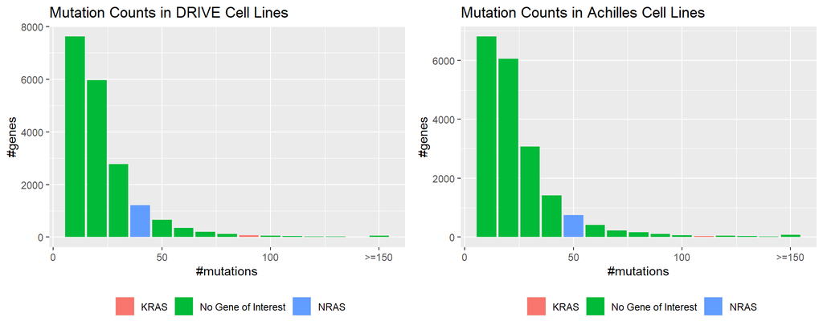

```r
mutation.plot.DRIVE <- create.mutation.counts.plot.mark("DRIVE",dep.scores.DRIVE,
                                                   cancer.names,CCLE.mut)

mutation.plot.Achilles <- create.mutation.counts.plot.mark("Achilles",
                                                      dep.scores.Achilles,
                                                      cancer.names,CCLE.mut)

grid.arrange(mutation.plot.DRIVE,mutation.plot.Achilles,ncol=2)
```

```r
rm(mutation.plot.DRIVE,mutation.plot.Achilles)
```

## Classification Tables for KRAS and NRAS

We create classification tables that show us for each cell line whether the selected genes are deleteriously mutated or not. Therefore we create one table where we check whether KRAS is deleteriously mutated, another table where we do the same for NRAS and a third table where we check whether at least one of KRAS and NRAS is deleteriously mutated.

```r
create.classification.table <- switch(classification.method,
                "del.vs.non.del" = create.classification.table.del.vs.non.del,
                "del.vs.non.mut" = create.classification.table.del.vs.non.mut,
                "mut.vs.non.mut" = create.classification.table.mut.vs.non.mut)

class.table.gene1 <- create.classification.table(
                                                CCLE.mut, cancer.names,
                                                gene1, dep.scores.DRIVE,
                                                dep.scores.Achilles)
class.table.gene2 <- create.classification.table(
                                                CCLE.mut, cancer.names,
                                                gene2, dep.scores.DRIVE,
                                                dep.scores.Achilles)

# merge tables
class.table.comb.DRIVE <- merge.class.tables(class.table.gene1$DRIVE,
                                             class.table.gene2$DRIVE)

class.table.comb.Achilles <- merge.class.tables(class.table.gene1$Achilles,
                                             class.table.gene2$Achilles)

knitr::kable(head(class.table.comb.DRIVE), format = "html",
             table.attr = "style='width:50%;'",
             caption = "Significant Genes in DRIVE")
```

| CCLE_ID | isDeleterious |
| --- | --- |
| 127399_SOFT_TISSUE | FALSE |
| 1321N1_CENTRAL_NERVOUS_SYSTEM | FALSE |
| 2313287_STOMACH | FALSE |
| 697_HAEMATOPOIETIC_AND_LYMPHOID_TISSUE | TRUE |
| 769P_KIDNEY | FALSE |
| 786O_KIDNEY | FALSE |

```r
rm(CCLE.mut,cancer.names)
```

## Classifications for KRAS

To check whether the samples sizes regarding KRAS for the following statistical tests are sufficient, we plot the number of cell lines for both samples.

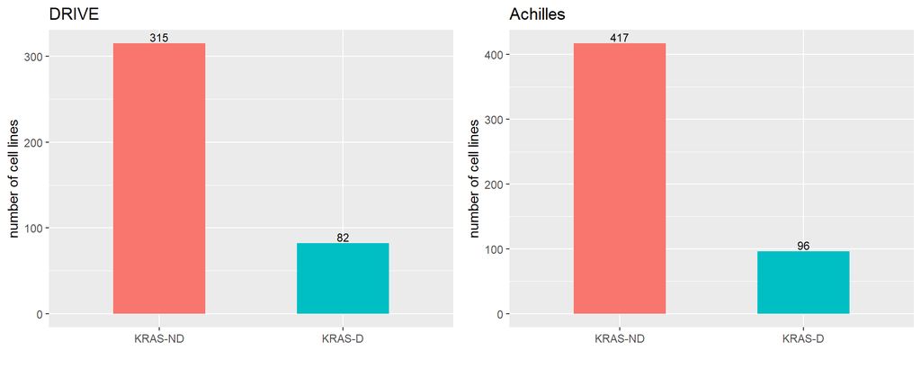

```r
barcharts.gene1 <- create_barcharts_classifications(class.table.gene1$DRIVE,
                                              class.table.gene1$Achilles,
                                              gene1)
plot_grid(barcharts.gene1$DRIVE, barcharts.gene1$Achilles)
```

```r
rm(barcharts.gene1)
```

## Classifications for NRAS

We repeat the plots for NRAS.

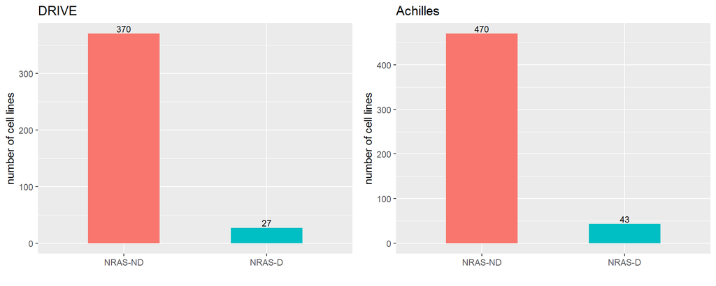

```r
barcharts.gene2 <- create_barcharts_classifications(class.table.gene2$DRIVE,
                                              class.table.gene2$Achilles,
                                              gene2)
plot_grid(barcharts.gene2$DRIVE, barcharts.gene2$Achilles)
```

```r
rm(barcharts.gene2)
```

## Classifications for KRASand NRAS

We repeat the plots for KRASand NRAS.

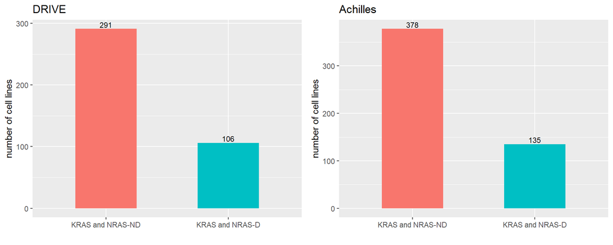

```r
barcharts.comb.genes <- create_barcharts_classifications(class.table.comb.DRIVE,
                                              class.table.comb.Achilles,
                                              paste(gene1,"and",gene2))
plot_grid(barcharts.comb.genes$DRIVE, barcharts.comb.genes$Achilles)
```

```r
rm(barcharts.comb.genes)
```

# Data Analysis KRAS

In order to detect differences between both samples, we compare them for each gene in the datasets DRIVE and Achilles. The workflow was published by [Chan et al., 2019](https://www.nature.com/articles/s41586-019-1102-x).

## Mean Differences

To test whether the two groups respond differently to the knock out or the knock down of a specific gene, we calculate the mean differences between the two groups for each gene.

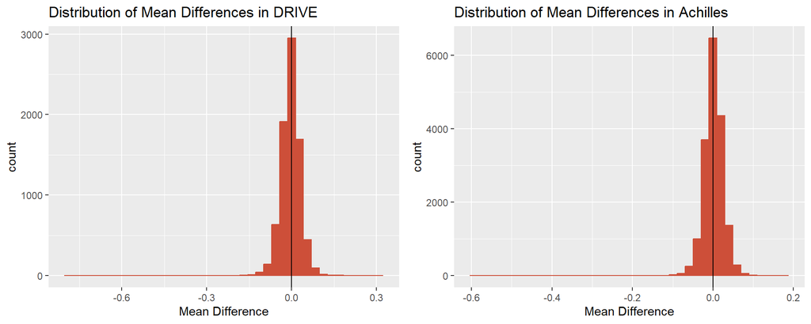

```r
test.results.gene1 <- calc.mean.diffs.and.p.values(dep.scores.DRIVE,
                                           dep.scores.Achilles,
                                           class.table.gene1$DRIVE,
                                           class.table.gene1$Achilles)

plots <- plot.mean.diffs(test.results.gene1)
grid.arrange(plots$DRIVE,plots$Achilles,ncol=2)
```

```r
rm(class.table.gene1,plots)
```

## Welch Test

The Welch t-test checks whether the means of two samples are identical. The prerequisite is that both samples are normally distributed, which we have not yet ensured.

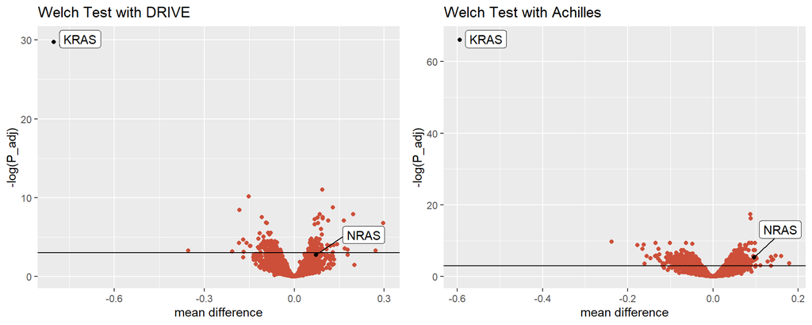

```r
plot.welch.DRIVE.gene1 <- create_volcano_plot(test.results.gene1,"DRIVE",
                                              "welch",target.genes,
                                              show_sign_line=T)

plot.welch.Achilles.gene1 <- create_volcano_plot(test.results.gene1,"Achilles",
                                                "welch",target.genes)

grid.arrange(plot.welch.DRIVE.gene1,plot.welch.Achilles.gene1,ncol=2)
```

```r
rm(plot.welch.DRIVE.gene1,plot.welch.Achilles.gene1)
```

To discover new potential dependencies, the table shows all significant genes.

```r
significant.genes.table.DRIVE.gene1 <- create.significant.genes.table(
  test.results.gene1,"DRIVE","welch")
significant.genes.table.Achilles.gene1 <- create.significant.genes.table(
  test.results.gene1,"Achilles","welch")

knitr::kable(significant.genes.table.DRIVE.gene1, format = "html",
             table.attr = "style='width:50%;'",
             caption = "Significant Genes in DRIVE")
```

Table 2: Significant Genes in DRIVE

|  | gene | p_value | p_adj | log |
| --- | --- | --- | --- | --- |
| 3620 | KRAS | 0.0000000 | 0.0000000 | 29.730301 |
| 1828 | ETV5 | 0.0000000 | 0.0000163 | 11.024975 |
| 2909 | GPT | 0.0000000 | 0.0000384 | 10.168201 |
| 6072 | SOX10 | 0.0000001 | 0.0001552 | 8.771095 |
| 4788 | TRPM7 | 0.0000001 | 0.0002197 | 8.423141 |
| 1980 | RHOBTB3 | 0.0000003 | 0.0003641 | 7.918107 |
| 4200 | NSF | 0.0000003 | 0.0003641 | 7.918107 |
| 2310 | POTEH | 0.0000006 | 0.0005404 | 7.523284 |
| 4322 | PCDH8 | 0.0000006 | 0.0005404 | 7.523284 |
| 1953 | FGFR1 | 0.0000007 | 0.0005807 | 7.451303 |
| 3939 | MITF | 0.0000009 | 0.0006240 | 7.379364 |
| 1494 | TRPV3 | 0.0000011 | 0.0007043 | 7.258367 |
| 635 | FERMT2 | 0.0000014 | 0.0008311 | 7.092763 |
| 3207 | HOXD11 | 0.0000015 | 0.0008311 | 7.092763 |
| 4174 | NOTCH3 | 0.0000021 | 0.0011050 | 6.807907 |
| 1000 | CCR5 | 0.0000024 | 0.0011150 | 6.798943 |
| 1971 | COPZ1 | 0.0000025 | 0.0011150 | 6.798943 |
| 3429 | FOXK2 | 0.0000025 | 0.0011150 | 6.798943 |
| 5844 | TTC31 | 0.0000031 | 0.0013087 | 6.638693 |
| 2166 | FMOD | 0.0000060 | 0.0024098 | 6.028217 |
| 3399 | ZNF429 | 0.0000108 | 0.0039308 | 5.538900 |
| 6794 | TNKS2 | 0.0000108 | 0.0039308 | 5.538900 |
| 571 | ALDH1L1 | 0.0000123 | 0.0042480 | 5.461310 |
| 3889 | MBD1 | 0.0000145 | 0.0048152 | 5.335976 |
| 5063 | OGDHL | 0.0000156 | 0.0049869 | 5.300949 |
| 6352 | MAGED4&MAGED4B | 0.0000204 | 0.0062536 | 5.074597 |
| 7724 | ACVRL1 | 0.0000263 | 0.0077763 | 4.856673 |
| 5752 | SELL | 0.0000297 | 0.0081888 | 4.804982 |
| 7812 | SOX13 | 0.0000298 | 0.0081888 | 4.804982 |
| 2335 | NR5A2 | 0.0000315 | 0.0083835 | 4.781489 |

[output cut: 158 more lines]

```r
knitr::kable(significant.genes.table.Achilles.gene1, format = "html",
             table.attr = "style='width:50%;'",
             caption = "Significant Genes in Achilles")
```

Table 2: Significant Genes in Achilles

|  | gene | p_value | p_adj | log |
| --- | --- | --- | --- | --- |
| 7858 | KRAS | 0.0000000 | 0.0000000 | 66.021979 |
| 13043 | RRAS2 | 0.0000000 | 0.0000000 | 17.441743 |
| 9442 | MYCN | 0.0000000 | 0.0000001 | 16.153537 |
| 2884 | CFLAR | 0.0000000 | 0.0000593 | 9.733450 |
| 2906 | CHCHD2 | 0.0000001 | 0.0000887 | 9.330591 |
| 6387 | GYS2 | 0.0000000 | 0.0000887 | 9.330591 |
| 8278 | LMNB1 | 0.0000000 | 0.0000887 | 9.330591 |
| 9417 | MVK | 0.0000000 | 0.0000887 | 9.330591 |
| 14300 | SOS1 | 0.0000000 | 0.0000887 | 9.330591 |
| 16409 | UPF1 | 0.0000000 | 0.0000887 | 9.330591 |
| 10392 | OR1L8 | 0.0000001 | 0.0001089 | 9.125439 |
| 11567 | POLDIP3 | 0.0000001 | 0.0001326 | 8.928224 |
| 16438 | UROD | 0.0000001 | 0.0001448 | 8.840040 |
| 9463 | MYH9 | 0.0000001 | 0.0001522 | 8.790079 |
| 14282 | SOCS7 | 0.0000001 | 0.0001522 | 8.790079 |
| 6285 | GRPEL2 | 0.0000002 | 0.0001829 | 8.606431 |
| 16875 | YIPF5 | 0.0000002 | 0.0001829 | 8.606431 |
| 7283 | IRAK2 | 0.0000004 | 0.0003497 | 7.958506 |
| 129 | ACBD3 | 0.0000005 | 0.0004695 | 7.663902 |
| 4954 | FAM104A | 0.0000006 | 0.0004695 | 7.663902 |
| 8650 | MAP3K6 | 0.0000006 | 0.0004695 | 7.663902 |
| 12150 | PTK6 | 0.0000006 | 0.0004695 | 7.663902 |
| 12388 | RAF1 | 0.0000006 | 0.0004695 | 7.663902 |
| 16112 | TTC39A | 0.0000006 | 0.0004695 | 7.663902 |
| 5988 | GMNN | 0.0000007 | 0.0004742 | 7.653925 |
| 15120 | TECR | 0.0000008 | 0.0005760 | 7.459318 |
| 8676 | MAPK7 | 0.0000011 | 0.0006750 | 7.300870 |
| 12475 | RASSF8 | 0.0000012 | 0.0006750 | 7.300870 |
| 12985 | RPP40 | 0.0000011 | 0.0006750 | 7.300870 |
| 16641 | VWA1 | 0.0000012 | 0.0006750 | 7.300870 |

[output cut: 915 more lines]

```r
rm(significant.genes.table.DRIVE.gene1,significant.genes.table.Achilles.gene1)
```

## Wilcoxon Test

The Wilcoxon test checks whether, for randomly selected values X and Y from two samples, the probability of X being greater than Y is equal to the probability of Y being greater than X. The prerequisite is that the data are ordinary, which is fulfilled here.

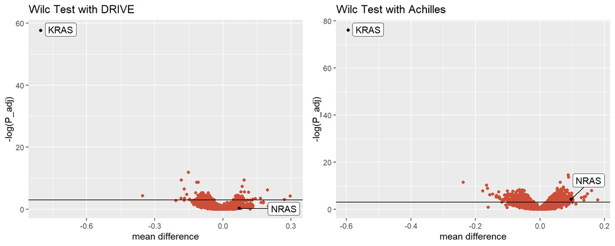

```r
plot.wilc.DRIVE.gene1 <- create_volcano_plot(test.results.gene1,"DRIVE","wilc",
                                       target.genes, show_sign_line=T)

plot.wilc.Achilles.gene1 <- create_volcano_plot(test.results.gene1,"Achilles",
                                                "wilc",target.genes)

grid.arrange(plot.wilc.DRIVE.gene1,plot.wilc.Achilles.gene1,ncol=2)
```

```r
rm(plot.wilc.DRIVE.gene1,plot.wilc.Achilles.gene1)
```

```r
significant.genes.table.DRIVE.gene1 <- create.significant.genes.table(
  test.results.gene1,"DRIVE","wilc")
significant.genes.table.Achilles.gene1 <- create.significant.genes.table(
  test.results.gene1,"Achilles","wilc")

knitr::kable(significant.genes.table.DRIVE.gene1, format = "html",
             table.attr = "style='width:50%;'",
             caption = "Significant Genes in DRIVE")
```

Table 3: Significant Genes in DRIVE

|  | gene | p_value | p_adj | log |
| --- | --- | --- | --- | --- |
| 3620 | KRAS | 0.0000000 | 0.0000000 | 57.623412 |
| 2909 | GPT | 0.0000000 | 0.0000072 | 11.847528 |
| 1828 | ETV5 | 0.0000000 | 0.0000836 | 9.388994 |
| 4788 | TRPM7 | 0.0000000 | 0.0000836 | 9.388994 |
| 571 | ALDH1L1 | 0.0000001 | 0.0001594 | 8.744001 |
| 4322 | PCDH8 | 0.0000001 | 0.0001594 | 8.744001 |
| 1980 | RHOBTB3 | 0.0000006 | 0.0006381 | 7.357077 |
| 1440 | ADSL | 0.0000015 | 0.0014645 | 6.526211 |
| 4200 | NSF | 0.0000022 | 0.0019855 | 6.221909 |
| 2310 | POTEH | 0.0000052 | 0.0037590 | 5.583601 |
| 3429 | FOXK2 | 0.0000049 | 0.0037590 | 5.583601 |
| 3207 | HOXD11 | 0.0000061 | 0.0040585 | 5.506933 |
| 1000 | CCR5 | 0.0000092 | 0.0048977 | 5.318984 |
| 3399 | ZNF429 | 0.0000090 | 0.0048977 | 5.318984 |
| 5700 | SAT1 | 0.0000087 | 0.0048977 | 5.318984 |
| 4174 | NOTCH3 | 0.0000109 | 0.0051317 | 5.272326 |
| 5752 | SELL | 0.0000104 | 0.0051317 | 5.272326 |
| 2349 | CADM2 | 0.0000185 | 0.0081361 | 4.811441 |
| 4426 | PPME1 | 0.0000194 | 0.0081361 | 4.811441 |
| 6915 | CDC7 | 0.0000204 | 0.0081361 | 4.811441 |
| 5063 | OGDHL | 0.0000234 | 0.0088852 | 4.723365 |
| 6794 | TNKS2 | 0.0000318 | 0.0115235 | 4.463366 |
| 1494 | TRPV3 | 0.0000391 | 0.0119885 | 4.423808 |
| 2340 | ALPPL2 | 0.0000349 | 0.0119885 | 4.423808 |
| 3596 | KIF5A | 0.0000374 | 0.0119885 | 4.423808 |
| 6898 | TMEM187 | 0.0000378 | 0.0119885 | 4.423808 |
| 4329 | GMNN | 0.0000422 | 0.0120308 | 4.420289 |
| 5106 | ECHDC1 | 0.0000409 | 0.0120308 | 4.420289 |
| 4715 | RBM47 | 0.0000440 | 0.0120978 | 4.414733 |
| 4397 | CDK18 | 0.0000466 | 0.0123845 | 4.391307 |

[output cut: 114 more lines]

```r
knitr::kable(significant.genes.table.Achilles.gene1, format = "html",
             table.attr = "style='width:50%;'",
             caption = "Significant Genes in Achilles")
```

Table 3: Significant Genes in Achilles

|  | gene | p_value | p_adj | log |
| --- | --- | --- | --- | --- |
| 7858 | KRAS | 0.0000000 | 0.0000000 | 76.150714 |
| 13043 | RRAS2 | 0.0000000 | 0.0000005 | 14.593933 |
| 9442 | MYCN | 0.0000000 | 0.0000012 | 13.596750 |
| 2884 | CFLAR | 0.0000000 | 0.0000103 | 11.481020 |
| 6285 | GRPEL2 | 0.0000000 | 0.0000103 | 11.481020 |
| 12388 | RAF1 | 0.0000000 | 0.0000337 | 10.296892 |
| 12150 | PTK6 | 0.0000000 | 0.0000861 | 9.360538 |
| 10189 | NUP210 | 0.0000001 | 0.0001337 | 8.919664 |
| 16438 | UROD | 0.0000001 | 0.0001337 | 8.919664 |
| 4954 | FAM104A | 0.0000001 | 0.0001717 | 8.669712 |
| 6387 | GYS2 | 0.0000001 | 0.0002246 | 8.401231 |
| 14282 | SOCS7 | 0.0000002 | 0.0002533 | 8.281104 |
| 335 | ADPRHL2 | 0.0000002 | 0.0002539 | 8.278688 |
| 1284 | BAIAP2L2 | 0.0000002 | 0.0002582 | 8.261644 |
| 15778 | TOX3 | 0.0000002 | 0.0002582 | 8.261644 |
| 8278 | LMNB1 | 0.0000002 | 0.0002585 | 8.260730 |
| 1839 | C1orf95 | 0.0000003 | 0.0002716 | 8.211233 |
| 8780 | MCL1 | 0.0000004 | 0.0003744 | 7.890099 |
| 10392 | OR1L8 | 0.0000004 | 0.0003744 | 7.890099 |
| 6245 | GREM2 | 0.0000005 | 0.0003838 | 7.865409 |
| 6473 | HDAC1 | 0.0000005 | 0.0003838 | 7.865409 |
| 10592 | OR5K3 | 0.0000005 | 0.0003838 | 7.865409 |
| 12475 | RASSF8 | 0.0000005 | 0.0003838 | 7.865409 |
| 16409 | UPF1 | 0.0000005 | 0.0004014 | 7.820544 |
| 9463 | MYH9 | 0.0000006 | 0.0004391 | 7.730741 |
| 8646 | MAP3K2 | 0.0000007 | 0.0004569 | 7.691094 |
| 2599 | CD58 | 0.0000007 | 0.0004590 | 7.686560 |
| 16112 | TTC39A | 0.0000007 | 0.0004590 | 7.686560 |
| 7283 | IRAK2 | 0.0000008 | 0.0004743 | 7.653656 |
| 11567 | POLDIP3 | 0.0000008 | 0.0004743 | 7.653656 |

[output cut: 1120 more lines]

```r
rm(significant.genes.table.DRIVE.gene1,significant.genes.table.Achilles.gene1)
```

## Bayes Test

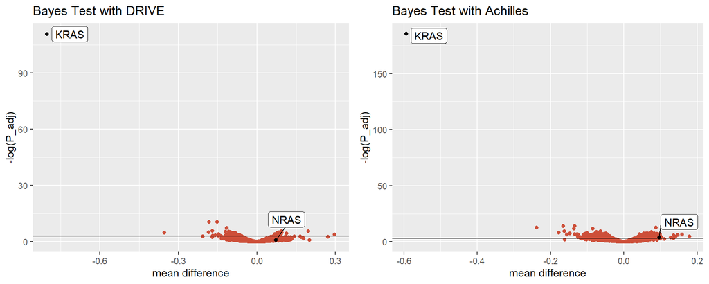

```r
plot.bayes.DRIVE.gene1 <- create_volcano_plot(test.results.gene1,"DRIVE","bayes",
                                       target.genes)

plot.bayes.Achilles.gene1 <- create_volcano_plot(test.results.gene1,"Achilles",
                                                "bayes",target.genes)

grid.arrange(plot.bayes.DRIVE.gene1,plot.bayes.Achilles.gene1,ncol=2)
```

```r
rm(plot.bayes.DRIVE.gene1,plot.bayes.Achilles.gene1)
```

```r
significant.genes.table.DRIVE.gene1 <- create.significant.genes.table(
  test.results.gene1,"DRIVE","bayes")
significant.genes.table.Achilles.gene1 <- create.significant.genes.table(
  test.results.gene1,"Achilles","bayes")

knitr::kable(significant.genes.table.DRIVE.gene1, format = "html",
             table.attr = "style='width:50%;'",
             caption = "Significant Genes in DRIVE")
```

Table 4: Significant Genes in DRIVE

|  | gene | p_adj | log |
| --- | --- | --- | --- |
| 3620 | KRAS | 0.0000000 | 110.732483 |
| 2909 | GPT | 0.0000253 | 10.585644 |
| 4788 | TRPM7 | 0.0000253 | 10.585644 |
| 571 | ALDH1L1 | 0.0005899 | 7.435623 |
| 1440 | ADSL | 0.0029901 | 5.812441 |
| 1828 | ETV5 | 0.0040255 | 5.515118 |
| 4200 | NSF | 0.0040255 | 5.515118 |
| 4322 | PCDH8 | 0.0048195 | 5.335081 |
| 5752 | SELL | 0.0048195 | 5.335081 |
| 4426 | PPME1 | 0.0056350 | 5.178752 |
| 592 | WDR3 | 0.0069517 | 4.968767 |
| 1980 | RHOBTB3 | 0.0069517 | 4.968767 |
| 5063 | OGDHL | 0.0084999 | 4.767699 |
| 1357 | CTNNB1 | 0.0087332 | 4.740626 |
| 2310 | POTEH | 0.0087332 | 4.740626 |
| 1000 | CCR5 | 0.0092803 | 4.679860 |
| 2349 | CADM2 | 0.0092803 | 4.679860 |
| 7812 | SOX13 | 0.0092803 | 4.679860 |
| 6920 | FZD4 | 0.0102305 | 4.582382 |
| 6352 | MAGED4&MAGED4B | 0.0108818 | 4.520664 |
| 3596 | KIF5A | 0.0118638 | 4.434260 |
| 3399 | ZNF429 | 0.0120349 | 4.419947 |
| 3207 | HOXD11 | 0.0129055 | 4.350104 |
| 518 | MAP3K2 | 0.0166603 | 4.094728 |
| 5011 | FERMT1 | 0.0166603 | 4.094728 |
| 3889 | MBD1 | 0.0177647 | 4.030540 |
| 7652 | WDR46 | 0.0182953 | 4.001111 |
| 2340 | ALPPL2 | 0.0183646 | 3.997332 |
| 5844 | TTC31 | 0.0199917 | 3.912440 |
| 1971 | COPZ1 | 0.0223796 | 3.799603 |
| 6794 | TNKS2 | 0.0223796 | 3.799603 |
| 1802 | ERBB4 | 0.0234781 | 3.751687 |
| 2166 | FMOD | 0.0234781 | 3.751687 |
| 6210 | BTN1A1 | 0.0234781 | 3.751687 |
| 7438 | RAB29 | 0.0234781 | 3.751687 |
| 6539 | ZNF202 | 0.0244297 | 3.711954 |
| 993 | SOCS4 | 0.0248175 | 3.696207 |
| 4174 | NOTCH3 | 0.0248175 | 3.696207 |
| 3429 | FOXK2 | 0.0248320 | 3.695622 |
| 3540 | KCNF1 | 0.0248320 | 3.695622 |
| 4329 | GMNN | 0.0248320 | 3.695622 |
| 4397 | CDK18 | 0.0248336 | 3.695556 |
| 1494 | TRPV3 | 0.0254088 | 3.672659 |
| 1389 | FGD5 | 0.0263661 | 3.635675 |
| 3832 | MIR200A | 0.0263661 | 3.635675 |
| 4650 | FXYD5 | 0.0278015 | 3.582666 |
| 4570 | SERPINA1 | 0.0295848 | 3.520495 |
| 1656 | TYMP | 0.0305833 | 3.487302 |
| 6634 | SPAG16 | 0.0316304 | 3.453636 |
| 6915 | CDC7 | 0.0316304 | 3.453636 |
| 5700 | SAT1 | 0.0345315 | 3.365883 |
| 6677 | LRRC31 | 0.0345315 | 3.365883 |
| 353 | RAPGEF3 | 0.0351413 | 3.348377 |
| 6574 | CAD | 0.0351413 | 3.348377 |
| 7724 | ACVRL1 | 0.0358735 | 3.327755 |
| 2412 | NEGR1 | 0.0377362 | 3.277134 |
| 6708 | PRR5L | 0.0377362 | 3.277134 |
| 7419 | PRPF4B | 0.0386663 | 3.252787 |
| 114 | ATP6V1G2-DDX39B | 0.0413272 | 3.186235 |
| 3782 | WDR38 | 0.0413272 | 3.186235 |
| 2980 | GSK3B | 0.0446908 | 3.107989 |
| 2555 | GATA6 | 0.0479622 | 3.037341 |
| 1286 | RAD9B | 0.0488880 | 3.018223 |
| 3764 | GRAPL | 0.0488880 | 3.018223 |
| 7753 | CHST2 | 0.0488880 | 3.018223 |
| 5332 | PTGFRN | 0.0496730 | 3.002293 |

```r
knitr::kable(significant.genes.table.Achilles.gene1, format = "html",
             table.attr = "style='width:50%;'",
             caption = "Significant Genes in Achilles")
```

Table 4: Significant Genes in Achilles

|  | gene | p_adj | log |
| --- | --- | --- | --- |
| 7858 | KRAS | 0.0000000 | 185.400254 |
| 4243 | DOCK5 | 0.0000008 | 14.074493 |
| 12388 | RAF1 | 0.0000008 | 14.026724 |
| 2884 | CFLAR | 0.0000034 | 12.587103 |
| 13043 | RRAS2 | 0.0000036 | 12.547503 |
| 8646 | MAP3K2 | 0.0000088 | 11.642921 |
| 15071 | TCF7L2 | 0.0000100 | 11.509059 |
| 6387 | GYS2 | 0.0000792 | 9.442932 |
| 16438 | UROD | 0.0000792 | 9.442932 |
| 8676 | MAPK7 | 0.0001710 | 8.673661 |
| 11930 | PROSER1 | 0.0001770 | 8.639164 |
| 14282 | SOCS7 | 0.0001991 | 8.521508 |
| 16409 | UPF1 | 0.0003590 | 7.932221 |
| 9463 | MYH9 | 0.0003754 | 7.887593 |
| 12475 | RASSF8 | 0.0005049 | 7.591230 |
| 10392 | OR1L8 | 0.0005571 | 7.492755 |
| 129 | ACBD3 | 0.0006062 | 7.408282 |
| 2737 | CDKN2D | 0.0006062 | 7.408282 |
| 4786 | ERGIC2 | 0.0006062 | 7.408282 |
| 6958 | ID1 | 0.0006062 | 7.408282 |
| 7225 | INSIG1 | 0.0006062 | 7.408282 |
| 16112 | TTC39A | 0.0006062 | 7.408282 |
| 3617 | CTNNB1 | 0.0006178 | 7.389333 |
| 4810 | ERP44 | 0.0006191 | 7.387209 |
| 4954 | FAM104A | 0.0006191 | 7.387209 |
| 10189 | NUP210 | 0.0006191 | 7.387209 |
| 10565 | OR5AC2 | 0.0006191 | 7.387209 |
| 12150 | PTK6 | 0.0006191 | 7.387209 |
| 16641 | VWA1 | 0.0006191 | 7.387209 |
| 2731 | CDKN1C | 0.0006281 | 7.372853 |

[output cut: 730 more lines]

```r
rm(significant.genes.table.DRIVE.gene1,significant.genes.table.Achilles.gene1,
   test.results.gene1)
```

# Data Analysis NRAS

We do the same for NRAS.

## Mean Differences

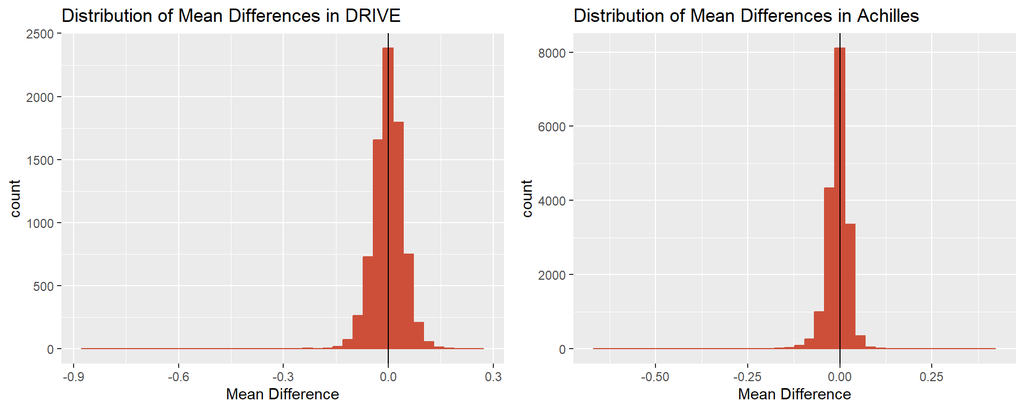

```r
test.results.gene2 <- calc.mean.diffs.and.p.values(dep.scores.DRIVE,
                                           dep.scores.Achilles,
                                           class.table.gene2$DRIVE,
                                           class.table.gene2$Achilles)

plots <- plot.mean.diffs(test.results.gene2)
grid.arrange(plots$DRIVE,plots$Achilles,ncol=2)
```

```r
rm(class.table.gene2,plots)
```

## Welch Test

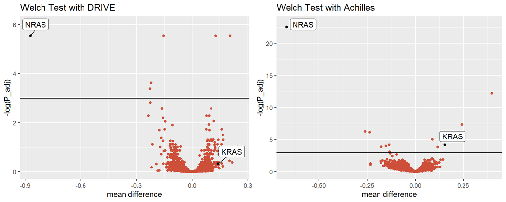

```r
plot.welch.DRIVE.gene2 <- create_volcano_plot(test.results.gene2,"DRIVE",
                                              "welch",target.genes,
                                              show_sign_line=T)

plot.welch.Achilles.gene2 <- create_volcano_plot(test.results.gene2,"Achilles",
                                                "welch",target.genes)

grid.arrange(plot.welch.DRIVE.gene2,plot.welch.Achilles.gene2,ncol=2)
```

```r
rm(plot.welch.DRIVE.gene2,plot.welch.Achilles.gene2)
```

```r
significant.genes.table.DRIVE.gene2 <- create.significant.genes.table(
  test.results.gene2,"DRIVE","welch")
significant.genes.table.Achilles.gene2 <- create.significant.genes.table(
  test.results.gene2,"Achilles","welch")

knitr::kable(significant.genes.table.DRIVE.gene2, format = "html",
             table.attr = "style='width:50%;'",
             caption = "Significant Genes in DRIVE")
```

Table 5: Significant Genes in DRIVE

|  | gene | p_value | p_adj | log |
| --- | --- | --- | --- | --- |
| 632 | TMED10 | 1.20e-06 | 0.0039627 | 5.530820 |
| 4194 | NRAS | 6.00e-07 | 0.0039627 | 5.530820 |
| 4513 | GHRL | 2.00e-06 | 0.0039627 | 5.530820 |
| 6196 | HNF1B | 1.80e-06 | 0.0039627 | 5.530820 |
| 2184 | ARHGEF18 | 1.67e-05 | 0.0266197 | 3.626103 |
| 2362 | MCM9 | 2.55e-05 | 0.0338384 | 3.386160 |

```r
knitr::kable(significant.genes.table.Achilles.gene2, format = "html",
             table.attr = "style='width:50%;'",
             caption = "Significant Genes in Achilles")
```

Table 5: Significant Genes in Achilles

|  | gene | p_value | p_adj | log |
| --- | --- | --- | --- | --- |
| 10065 | NRAS | 0.00e+00 | 0.0000000 | 22.554870 |
| 6240 | GRB2 | 0.00e+00 | 0.0000049 | 12.226599 |
| 12166 | PTPN11 | 1.00e-07 | 0.0006149 | 7.394024 |
| 12388 | RAF1 | 4.00e-07 | 0.0018500 | 6.292584 |
| 13625 | SHOC2 | 6.00e-07 | 0.0020807 | 6.175027 |
| 5660 | GAB1 | 2.20e-06 | 0.0064591 | 5.042263 |
| 7858 | KRAS | 6.80e-06 | 0.0150594 | 4.195753 |
| 11783 | PPP4C | 6.50e-06 | 0.0150594 | 4.195753 |
| 9114 | MORF4L1 | 9.20e-06 | 0.0180136 | 4.016630 |
| 6058 | GOLGA7 | 1.15e-05 | 0.0202926 | 3.897498 |
| 4522 | EGFR | 1.31e-05 | 0.0209437 | 3.865920 |
| 5669 | GABPB1 | 3.03e-05 | 0.0445709 | 3.110673 |

```r
rm(significant.genes.table.DRIVE.gene2,significant.genes.table.Achilles.gene2)
```

## Wilcoxon Test

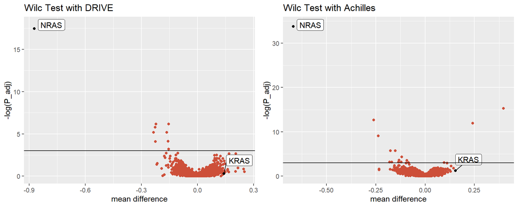

```r
plot.wilc.DRIVE.gene2 <- create_volcano_plot(test.results.gene2,"DRIVE","wilc",
                                       target.genes, show_sign_line=T)

plot.wilc.Achilles.gene2 <- create_volcano_plot(test.results.gene2,"Achilles",
                                                "wilc",target.genes)

grid.arrange(plot.wilc.DRIVE.gene2,plot.wilc.Achilles.gene2,ncol=2)
```

```r
rm(plot.wilc.DRIVE.gene2,plot.wilc.Achilles.gene2)
```

```r
significant.genes.table.DRIVE.gene2 <- create.significant.genes.table(
  test.results.gene2,"DRIVE","wilc")
significant.genes.table.Achilles.gene2 <- create.significant.genes.table(
  test.results.gene2,"Achilles","wilc")

knitr::kable(significant.genes.table.DRIVE.gene2, format = "html",
             table.attr = "style='width:50%;'",
             caption = "Significant Genes in DRIVE")
```

Table 6: Significant Genes in DRIVE

|  | gene | p_value | p_adj | log |
| --- | --- | --- | --- | --- |
| 4194 | NRAS | 0.00e+00 | 0.0000000 | 17.474261 |
| 4513 | GHRL | 5.00e-07 | 0.0021114 | 6.160415 |
| 2184 | ARHGEF18 | 8.00e-07 | 0.0021201 | 6.156271 |
| 2362 | MCM9 | 1.50e-06 | 0.0030402 | 5.795824 |
| 6795 | SHOC2 | 4.00e-06 | 0.0056484 | 5.176391 |
| 6857 | TSSK3 | 4.20e-06 | 0.0056484 | 5.176391 |
| 3535 | ANKRD36 | 1.44e-05 | 0.0164305 | 4.108618 |
| 541 | LOC107984065 | 1.70e-05 | 0.0169285 | 4.078757 |
| 4731 | ING3 | 4.54e-05 | 0.0402617 | 3.212355 |

```r
knitr::kable(significant.genes.table.Achilles.gene2, format = "html",
             table.attr = "style='width:50%;'",
             caption = "Significant Genes in Achilles")
```

Table 6: Significant Genes in Achilles

|  | gene | p_value | p_adj | log |
| --- | --- | --- | --- | --- |
| 10065 | NRAS | 0.00e+00 | 0.0000000 | 33.764759 |
| 6240 | GRB2 | 0.00e+00 | 0.0000002 | 15.287694 |
| 12388 | RAF1 | 0.00e+00 | 0.0000031 | 12.690801 |
| 12166 | PTPN11 | 0.00e+00 | 0.0000067 | 11.911625 |
| 13625 | SHOC2 | 0.00e+00 | 0.0001169 | 9.053978 |
| 6058 | GOLGA7 | 1.20e-06 | 0.0031609 | 5.756905 |
| 9114 | MORF4L1 | 1.30e-06 | 0.0031609 | 5.756905 |
| 2907 | CHCHD3 | 6.00e-06 | 0.0132185 | 4.326141 |
| 5669 | GABPB1 | 1.37e-05 | 0.0269077 | 3.615343 |
| 7088 | IKZF1 | 1.67e-05 | 0.0294338 | 3.525613 |
| 3309 | COLCA2 | 3.11e-05 | 0.0408475 | 3.197910 |
| 8838 | MED24 | 3.17e-05 | 0.0408475 | 3.197910 |
| 9168 | MRGBP | 3.24e-05 | 0.0408475 | 3.197910 |
| 11783 | PPP4C | 2.67e-05 | 0.0408475 | 3.197910 |
| 1279 | BAHD1 | 4.29e-05 | 0.0472954 | 3.051343 |
| 10880 | PARVA | 4.29e-05 | 0.0472954 | 3.051343 |

```r
rm(significant.genes.table.DRIVE.gene2,significant.genes.table.Achilles.gene2)
```

## Bayes Test

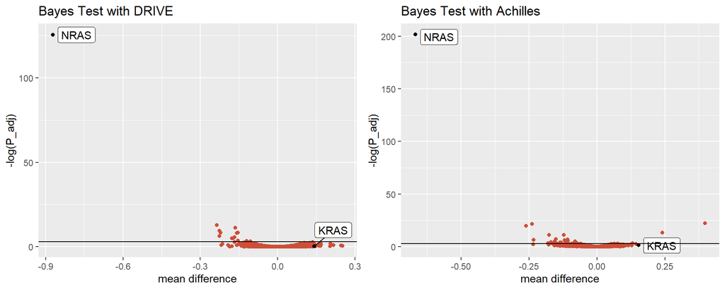

```r
plot.bayes.DRIVE.gene2 <- create_volcano_plot(test.results.gene2,"DRIVE","bayes",
                                       target.genes)

plot.bayes.Achilles.gene2 <- create_volcano_plot(test.results.gene2,"Achilles",
                                                "bayes",target.genes)

grid.arrange(plot.bayes.DRIVE.gene2,plot.bayes.Achilles.gene2,ncol=2)
```

```r
rm(plot.bayes.DRIVE.gene2,plot.bayes.Achilles.gene2)
```

```r
significant.genes.table.DRIVE.gene2 <- create.significant.genes.table(
  test.results.gene2,"DRIVE","bayes")
significant.genes.table.Achilles.gene2 <- create.significant.genes.table(
  test.results.gene2,"Achilles","bayes")

knitr::kable(significant.genes.table.DRIVE.gene2, format = "html",
             table.attr = "style='width:50%;'",
             caption = "Significant Genes in DRIVE")
```

Table 7: Significant Genes in DRIVE

|  | gene | p_adj | log |
| --- | --- | --- | --- |
| 4194 | NRAS | 0.0000000 | 125.427242 |
| 6795 | SHOC2 | 0.0000029 | 12.746940 |
| 6857 | TSSK3 | 0.0000147 | 11.127930 |
| 2362 | MCM9 | 0.0000859 | 9.361909 |
| 2184 | ARHGEF18 | 0.0002287 | 8.383156 |
| 4513 | GHRL | 0.0002287 | 8.383156 |
| 3535 | ANKRD36 | 0.0002956 | 8.126597 |
| 541 | LOC107984065 | 0.0018139 | 6.312264 |
| 5530 | RAF1 | 0.0033609 | 5.695554 |
| 2804 | UTS2R | 0.0064286 | 5.046997 |
| 4319 | SOST | 0.0068349 | 4.985715 |
| 4731 | ING3 | 0.0237142 | 3.741682 |
| 1985 | ANKRD26 | 0.0324463 | 3.428170 |
| 6084 | SPG7 | 0.0398350 | 3.223009 |

```r
knitr::kable(significant.genes.table.Achilles.gene2, format = "html",
             table.attr = "style='width:50%;'",
             caption = "Significant Genes in Achilles")
```

Table 7: Significant Genes in Achilles

|  | gene | p_adj | log |
| --- | --- | --- | --- |
| 10065 | NRAS | 0.0000000 | 201.568058 |
| 6240 | GRB2 | 0.0000000 | 22.316905 |
| 13625 | SHOC2 | 0.0000000 | 21.466882 |
| 12388 | RAF1 | 0.0000000 | 19.845255 |
| 12166 | PTPN11 | 0.0000017 | 13.264172 |
| 3309 | COLCA2 | 0.0000122 | 11.315815 |
| 6058 | GOLGA7 | 0.0000122 | 11.315815 |
| 9114 | MORF4L1 | 0.0007926 | 7.140169 |
| 4150 | DMXL1 | 0.0010785 | 6.832141 |
| 7293 | IRF4 | 0.0015318 | 6.481309 |
| 2907 | CHCHD3 | 0.0018524 | 6.291247 |
| 12558 | RCE1 | 0.0025158 | 5.985163 |
| 3187 | CNBP | 0.0045644 | 5.389479 |
| 6308 | GSS | 0.0052523 | 5.249087 |
| 6503 | HECTD2 | 0.0063393 | 5.060987 |
| 8256 | LIPT1 | 0.0063940 | 5.052390 |
| 9168 | MRGBP | 0.0121296 | 4.412107 |
| 11783 | PPP4C | 0.0174606 | 4.047810 |
| 5669 | GABPB1 | 0.0195888 | 3.932796 |
| 1279 | BAHD1 | 0.0212943 | 3.849314 |
| 8838 | MED24 | 0.0323662 | 3.430641 |
| 12351 | RABGEF1 | 0.0323662 | 3.430641 |
| 1126 | ATP1B3 | 0.0324632 | 3.427650 |
| 1391 | BHMT | 0.0324632 | 3.427650 |
| 9801 | NFKB1 | 0.0324632 | 3.427650 |
| 12704 | RHEB | 0.0324632 | 3.427650 |
| 12581 | REC114 | 0.0373905 | 3.286339 |
| 4643 | EMC6 | 0.0444448 | 3.113507 |
| 13655 | SIK3 | 0.0444448 | 3.113507 |
| 6016 | GNB5 | 0.0451275 | 3.098263 |
| 1416 | BLOC1S3 | 0.0480424 | 3.035672 |
| 13775 | SLC20A1 | 0.0480424 | 3.035672 |
| 3626 | CTRB2 | 0.0495105 | 3.005571 |
| 8855 | MEF2C | 0.0499530 | 2.996672 |

```r
rm(significant.genes.table.DRIVE.gene2,significant.genes.table.Achilles.gene2,
   test.results.gene2)
```

# Data Analysis KRAS and NRAS

We do the same for KRAS and NRAS combined.

## Mean Differences

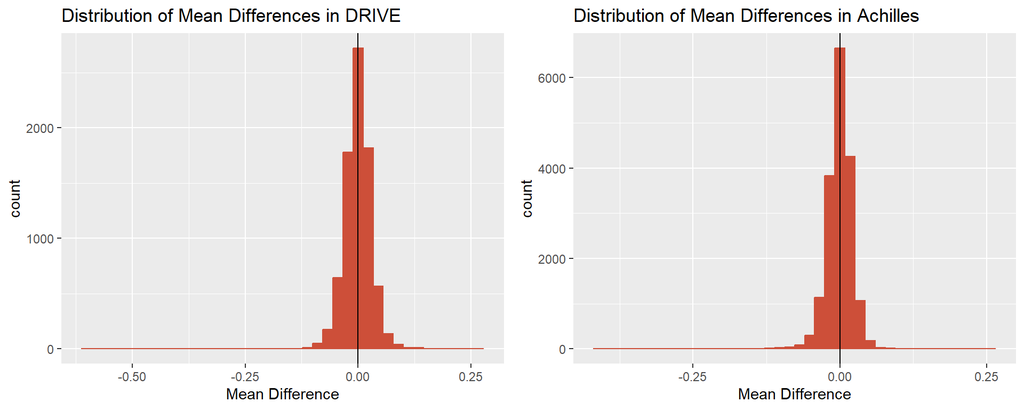

```r
test.results.gene12 <- calc.mean.diffs.and.p.values(dep.scores.DRIVE,
                                           dep.scores.Achilles,
                                           class.table.comb.DRIVE,
                                           class.table.comb.Achilles)

plots <- plot.mean.diffs(test.results.gene12)
grid.arrange(plots$DRIVE,plots$Achilles,ncol=2)
```

```r
rm(class.table.comb.DRIVE,class.table.comb.Achilles,plots)
```

## Welch Test

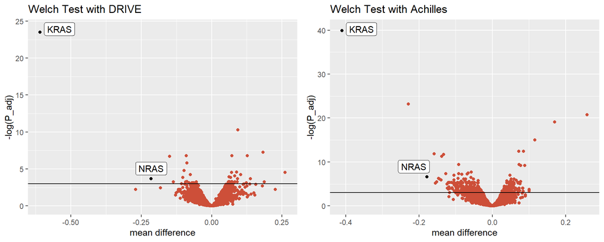

```r
plot.welch.DRIVE.gene12 <- create_volcano_plot(test.results.gene12,"DRIVE",
                                              "welch",target.genes)

plot.welch.Achilles.gene12 <- create_volcano_plot(test.results.gene12,"Achilles",
                                                "welch",target.genes)

grid.arrange(plot.welch.DRIVE.gene12,plot.welch.Achilles.gene12,ncol=2)
```

```r
rm(plot.welch.DRIVE.gene12,plot.welch.Achilles.gene12)
```

```r
significant.genes.table.DRIVE.gene12 <- create.significant.genes.table(
  test.results.gene12,"DRIVE","welch")
significant.genes.table.Achilles.gene12 <- create.significant.genes.table(
  test.results.gene12,"Achilles","welch")

knitr::kable(significant.genes.table.DRIVE.gene12, format = "html",
             table.attr = "style='width:50%;'",
             caption = "Significant Genes in DRIVE")
```

Table 8: Significant Genes in DRIVE

|  | gene | p_value | p_adj | log |
| --- | --- | --- | --- | --- |
| 3620 | KRAS | 0.0000000 | 0.0000000 | 23.520160 |
| 1828 | ETV5 | 0.0000000 | 0.0000347 | 10.269546 |
| 4200 | NSF | 0.0000003 | 0.0007071 | 7.254370 |
| 3399 | ZNF429 | 0.0000008 | 0.0011153 | 6.798663 |
| 5454 | PTPN11 | 0.0000008 | 0.0011153 | 6.798663 |
| 6898 | TMEM187 | 0.0000008 | 0.0011153 | 6.798663 |
| 4788 | TRPM7 | 0.0000011 | 0.0012102 | 6.717007 |
| 2122 | GGA3 | 0.0000030 | 0.0029844 | 5.814365 |
| 890 | CKM | 0.0000093 | 0.0082794 | 4.793982 |
| 409 | UBD | 0.0000130 | 0.0104005 | 4.565901 |
| 1971 | COPZ1 | 0.0000161 | 0.0109333 | 4.515940 |
| 7593 | HTR3B | 0.0000165 | 0.0109333 | 4.515940 |
| 560 | LOC107987587&PGM5P2 | 0.0000251 | 0.0143161 | 4.246368 |
| 6794 | TNKS2 | 0.0000246 | 0.0143161 | 4.246368 |
| 2912 | GRB2 | 0.0000328 | 0.0174423 | 4.048857 |
| 4910 | PPP2R3A | 0.0000388 | 0.0193508 | 3.945021 |
| 1953 | FGFR1 | 0.0000456 | 0.0213920 | 3.844737 |
| 5752 | SELL | 0.0000491 | 0.0217629 | 3.827550 |
| 6104 | BRAF | 0.0000594 | 0.0249355 | 3.691463 |
| 3207 | HOXD11 | 0.0000667 | 0.0253178 | 3.676246 |
| 4194 | NRAS | 0.0000653 | 0.0253178 | 3.676246 |
| 3782 | WDR38 | 0.0001040 | 0.0373223 | 3.288165 |
| 4494 | PDK2 | 0.0001093 | 0.0373223 | 3.288165 |
| 5486 | ABCD4 | 0.0001123 | 0.0373223 | 3.288165 |
| 1129 | COPA | 0.0001420 | 0.0384067 | 3.259524 |
| 2362 | MCM9 | 0.0001436 | 0.0384067 | 3.259524 |
| 2761 | GP2 | 0.0001372 | 0.0384067 | 3.259524 |
| 2817 | GPR18 | 0.0001532 | 0.0384067 | 3.259524 |
| 3790 | OR2T5 | 0.0001383 | 0.0384067 | 3.259524 |
| 3939 | MITF | 0.0001269 | 0.0384067 | 3.259524 |
| 6875 | RAB1B | 0.0001541 | 0.0384067 | 3.259524 |
| 7812 | SOX13 | 0.0001470 | 0.0384067 | 3.259524 |
| 1440 | ADSL | 0.0001771 | 0.0392323 | 3.238255 |
| 2412 | NEGR1 | 0.0001639 | 0.0392323 | 3.238255 |
| 3967 | MMP14 | 0.0001757 | 0.0392323 | 3.238255 |
| 4660 | RAB4B | 0.0001749 | 0.0392323 | 3.238255 |
| 449 | CCT7 | 0.0002132 | 0.0437928 | 3.128286 |
| 2310 | POTEH | 0.0002053 | 0.0437928 | 3.128286 |
| 2721 | EML4 | 0.0002263 | 0.0437928 | 3.128286 |
| 3443 | INPPL1 | 0.0002250 | 0.0437928 | 3.128286 |
| 3596 | KIF5A | 0.0002306 | 0.0437928 | 3.128286 |
| 5181 | ANKRD7 | 0.0002171 | 0.0437928 | 3.128286 |
| 1958 | FH | 0.0002570 | 0.0455467 | 3.089016 |
| 3429 | FOXK2 | 0.0002548 | 0.0455467 | 3.089016 |
| 5744 | NEUROD6 | 0.0002559 | 0.0455467 | 3.089016 |
| 5063 | OGDHL | 0.0002668 | 0.0462552 | 3.073582 |
| 2125 | PASK | 0.0002731 | 0.0463345 | 3.071868 |
| 3731 | LETM1 | 0.0002953 | 0.0490572 | 3.014769 |
| 2109 | PHF8 | 0.0003126 | 0.0498623 | 2.998490 |
| 5986 | MRPL45P2 | 0.0003078 | 0.0498623 | 2.998490 |

```r
knitr::kable(significant.genes.table.Achilles.gene12, format = "html",
             table.attr = "style='width:50%;'",
             caption = "Significant Genes in Achilles")
```

Table 8: Significant Genes in Achilles

|  | gene | p_value | p_adj | log |
| --- | --- | --- | --- | --- |
| 7858 | KRAS | 0.0000000 | 0.0000000 | 39.909219 |
| 12388 | RAF1 | 0.0000000 | 0.0000000 | 23.152768 |
| 6240 | GRB2 | 0.0000000 | 0.0000000 | 20.736344 |
| 12166 | PTPN11 | 0.0000000 | 0.0000000 | 19.082265 |
| 14300 | SOS1 | 0.0000000 | 0.0000003 | 15.006814 |
| 5578 | FRS2 | 0.0000000 | 0.0000039 | 12.455463 |
| 13043 | RRAS2 | 0.0000000 | 0.0000039 | 12.455463 |
| 16438 | UROD | 0.0000000 | 0.0000072 | 11.839509 |
| 9417 | MVK | 0.0000000 | 0.0000081 | 11.718743 |
| 13625 | SHOC2 | 0.0000000 | 0.0000129 | 11.258052 |
| 9442 | MYCN | 0.0000001 | 0.0000837 | 9.388414 |
| 10067 | NRBP1 | 0.0000001 | 0.0000837 | 9.388414 |
| 7225 | INSIG1 | 0.0000001 | 0.0001025 | 9.185940 |
| 4900 | EXT2 | 0.0000001 | 0.0001037 | 9.173802 |
| 11930 | PROSER1 | 0.0000004 | 0.0004656 | 7.672129 |
| 14033 | SLC7A10 | 0.0000005 | 0.0005658 | 7.477281 |
| 5990 | GMPPB | 0.0000006 | 0.0006681 | 7.311077 |
| 10267 | OGDH | 0.0000007 | 0.0006681 | 7.311077 |
| 1423 | BMF | 0.0000007 | 0.0006899 | 7.278959 |
| 14894 | TAF13 | 0.0000009 | 0.0007611 | 7.180778 |
| 1839 | C1orf95 | 0.0000011 | 0.0009530 | 6.955914 |
| 6700 | HMGCS1 | 0.0000012 | 0.0009547 | 6.954074 |
| 10065 | NRAS | 0.0000017 | 0.0013067 | 6.640269 |
| 13612 | SHF | 0.0000022 | 0.0015822 | 6.448923 |
| 16004 | TRPM7 | 0.0000027 | 0.0018694 | 6.282145 |
| 12371 | RAD51 | 0.0000029 | 0.0019388 | 6.245687 |
| 5211 | FARP1 | 0.0000035 | 0.0022618 | 6.091588 |
| 6285 | GRPEL2 | 0.0000037 | 0.0022628 | 6.091161 |
| 16968 | ZC3H4 | 0.0000037 | 0.0022628 | 6.091161 |
| 3623 | CTPS1 | 0.0000039 | 0.0022688 | 6.088506 |

[output cut: 539 more lines]

```r
rm(significant.genes.table.DRIVE.gene12,significant.genes.table.Achilles.gene12)
```

## Wilcoxon Test

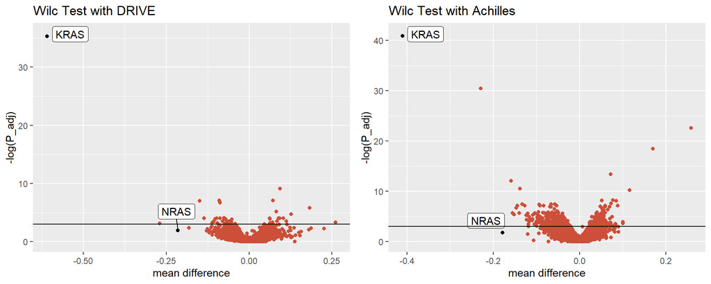

```r
plot.wilc.DRIVE.gene12 <- create_volcano_plot(test.results.gene12,"DRIVE","wilc",
                                       target.genes, show_sign_line=T)

plot.wilc.Achilles.gene12 <- create_volcano_plot(test.results.gene12,"Achilles",
                                                "wilc",target.genes)

grid.arrange(plot.wilc.DRIVE.gene12,plot.wilc.Achilles.gene12,ncol=2)
```

```r
rm(plot.wilc.DRIVE.gene12,plot.wilc.Achilles.gene12)
```

```r
significant.genes.table.DRIVE.gene12 <- create.significant.genes.table(
  test.results.gene12,"DRIVE","wilc")
significant.genes.table.Achilles.gene12 <- create.significant.genes.table(
  test.results.gene12,"Achilles","wilc")

knitr::kable(significant.genes.table.DRIVE.gene12, format = "html",
             table.attr = "style='width:50%;'",
             caption = "Significant Genes in DRIVE")
```

Table 9: Significant Genes in DRIVE

|  | gene | p_value | p_adj | log |
| --- | --- | --- | --- | --- |
| 3620 | KRAS | 0.0000000 | 0.0000000 | 35.306431 |
| 1828 | ETV5 | 0.0000000 | 0.0001120 | 9.096779 |
| 3399 | ZNF429 | 0.0000004 | 0.0008612 | 7.057169 |
| 6898 | TMEM187 | 0.0000003 | 0.0008612 | 7.057169 |
| 4788 | TRPM7 | 0.0000006 | 0.0009193 | 6.991882 |
| 2122 | GGA3 | 0.0000009 | 0.0012601 | 6.676560 |
| 4200 | NSF | 0.0000026 | 0.0029852 | 5.814087 |
| 2912 | GRB2 | 0.0000058 | 0.0057742 | 5.154353 |
| 5454 | PTPN11 | 0.0000098 | 0.0087128 | 4.742957 |
| 4322 | PCDH8 | 0.0000215 | 0.0171095 | 4.068122 |
| 409 | UBD | 0.0000371 | 0.0173919 | 4.051750 |
| 560 | LOC107987587&PGM5P2 | 0.0000321 | 0.0173919 | 4.051750 |
| 890 | CKM | 0.0000362 | 0.0173919 | 4.051750 |
| 1440 | ADSL | 0.0000297 | 0.0173919 | 4.051750 |
| 1980 | RHOBTB3 | 0.0000261 | 0.0173919 | 4.051750 |
| 3207 | HOXD11 | 0.0000335 | 0.0173919 | 4.051750 |
| 3782 | WDR38 | 0.0000287 | 0.0173919 | 4.051750 |
| 3429 | FOXK2 | 0.0000476 | 0.0205268 | 3.886025 |
| 3672 | RND3 | 0.0000519 | 0.0205268 | 3.886025 |
| 5752 | SELL | 0.0000513 | 0.0205268 | 3.886025 |
| 6794 | TNKS2 | 0.0000541 | 0.0205268 | 3.886025 |
| 5700 | SAT1 | 0.0000618 | 0.0223899 | 3.799145 |
| 632 | TMED10 | 0.0000954 | 0.0295178 | 3.522761 |
| 1958 | FH | 0.0000962 | 0.0295178 | 3.522761 |
| 3009 | PACSIN3 | 0.0000958 | 0.0295178 | 3.522761 |
| 3596 | KIF5A | 0.0000875 | 0.0295178 | 3.522761 |
| 5063 | OGDHL | 0.0001020 | 0.0301155 | 3.502716 |
| 2721 | EML4 | 0.0001136 | 0.0318831 | 3.445678 |
| 5986 | MRPL45P2 | 0.0001159 | 0.0318831 | 3.445678 |
| 1971 | COPZ1 | 0.0001397 | 0.0369326 | 3.298660 |
| 2817 | GPR18 | 0.0001528 | 0.0369326 | 3.298660 |
| 2948 | GRINA | 0.0001489 | 0.0369326 | 3.298660 |
| 7593 | HTR3B | 0.0001441 | 0.0369326 | 3.298660 |
| 4226 | OGDH | 0.0001599 | 0.0375072 | 3.283222 |
| 2310 | POTEH | 0.0001672 | 0.0380993 | 3.267559 |
| 2482 | TIPARP | 0.0001915 | 0.0412822 | 3.187324 |
| 7812 | SOX13 | 0.0001892 | 0.0412822 | 3.187324 |
| 932 | MRGPRX3 | 0.0002063 | 0.0432925 | 3.139775 |
| 571 | ALDH1L1 | 0.0002192 | 0.0436945 | 3.130534 |
| 1357 | CTNNB1 | 0.0002164 | 0.0436945 | 3.130534 |
| 1475 | CLEC12A | 0.0002532 | 0.0476616 | 3.043628 |
| 3790 | OR2T5 | 0.0002488 | 0.0476616 | 3.043628 |
| 6517 | SYS1-DBNDD2&SYS1 | 0.0002630 | 0.0476616 | 3.043628 |
| 7844 | GREB1 | 0.0002591 | 0.0476616 | 3.043628 |
| 6618 | HMGN5 | 0.0002798 | 0.0495938 | 3.003889 |

```r
knitr::kable(significant.genes.table.Achilles.gene12, format = "html",
             table.attr = "style='width:50%;'",
             caption = "Significant Genes in Achilles")
```

Table 9: Significant Genes in Achilles

|  | gene | p_value | p_adj | log |
| --- | --- | --- | --- | --- |
| 7858 | KRAS | 0.0000000 | 0.0000000 | 40.879925 |
| 12388 | RAF1 | 0.0000000 | 0.0000000 | 30.445001 |
| 6240 | GRB2 | 0.0000000 | 0.0000000 | 22.551901 |
| 12166 | PTPN11 | 0.0000000 | 0.0000000 | 18.442096 |
| 13043 | RRAS2 | 0.0000000 | 0.0000015 | 13.412063 |
| 16438 | UROD | 0.0000000 | 0.0000058 | 12.061378 |
| 13625 | SHOC2 | 0.0000000 | 0.0000265 | 10.537045 |
| 14300 | SOS1 | 0.0000000 | 0.0000355 | 10.247039 |
| 7225 | INSIG1 | 0.0000001 | 0.0002575 | 8.264459 |
| 6285 | GRPEL2 | 0.0000002 | 0.0002879 | 8.152911 |
| 5578 | FRS2 | 0.0000002 | 0.0003130 | 8.069252 |
| 9442 | MYCN | 0.0000004 | 0.0005183 | 7.565006 |
| 9417 | MVK | 0.0000005 | 0.0005808 | 7.451104 |
| 11930 | PROSER1 | 0.0000004 | 0.0005808 | 7.451104 |
| 14033 | SLC7A10 | 0.0000005 | 0.0005808 | 7.451104 |
| 12371 | RAD51 | 0.0000006 | 0.0006334 | 7.364399 |
| 4900 | EXT2 | 0.0000008 | 0.0007744 | 7.163449 |
| 10267 | OGDH | 0.0000008 | 0.0007744 | 7.163449 |
| 12150 | PTK6 | 0.0000008 | 0.0007744 | 7.163449 |
| 3623 | CTPS1 | 0.0000010 | 0.0008003 | 7.130509 |
| 10067 | NRBP1 | 0.0000010 | 0.0008003 | 7.130509 |
| 12581 | REC114 | 0.0000010 | 0.0008003 | 7.130509 |
| 14894 | TAF13 | 0.0000010 | 0.0008003 | 7.130509 |
| 1839 | C1orf95 | 0.0000012 | 0.0009038 | 7.008856 |
| 1237 | B3GALT6 | 0.0000014 | 0.0009826 | 6.925353 |
| 1262 | B4GALT7 | 0.0000015 | 0.0009826 | 6.925353 |
| 1423 | BMF | 0.0000015 | 0.0009826 | 6.925353 |
| 8646 | MAP3K2 | 0.0000016 | 0.0009826 | 6.925353 |
| 16004 | TRPM7 | 0.0000020 | 0.0011886 | 6.735003 |
| 335 | ADPRHL2 | 0.0000021 | 0.0012121 | 6.715360 |

[output cut: 678 more lines]

```r
rm(significant.genes.table.DRIVE.gene12,significant.genes.table.Achilles.gene12)
```

## Bayes Test

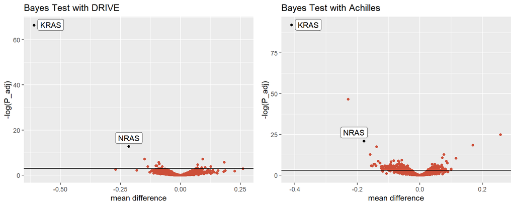

```r
plot.bayes.DRIVE.gene12 <- create_volcano_plot(test.results.gene12,"DRIVE",
                                               "bayes",target.genes)

plot.bayes.Achilles.gene12 <- create_volcano_plot(test.results.gene12,
                                                  "Achilles","bayes",
                                                  target.genes)

grid.arrange(plot.bayes.DRIVE.gene12,plot.bayes.Achilles.gene12,ncol=2)
```

```r
rm(plot.bayes.DRIVE.gene12,plot.bayes.Achilles.gene12)
```

```r
significant.genes.table.DRIVE.gene12 <- create.significant.genes.table(
  test.results.gene12,"DRIVE","bayes")
significant.genes.table.Achilles.gene12 <- create.significant.genes.table(
  test.results.gene12,"Achilles","bayes")

knitr::kable(significant.genes.table.DRIVE.gene12, format = "html",
             table.attr = "style='width:50%;'",
             caption = "Significant Genes in DRIVE")
```

Table 10: Significant Genes in DRIVE

|  | gene | p_adj | log |
| --- | --- | --- | --- |
| 3620 | KRAS | 0.0000000 | 66.402505 |
| 4194 | NRAS | 0.0000030 | 12.723106 |
| 4788 | TRPM7 | 0.0007665 | 7.173657 |
| 1828 | ETV5 | 0.0008077 | 7.121342 |
| 3399 | ZNF429 | 0.0033454 | 5.700178 |
| 4200 | NSF | 0.0033454 | 5.700178 |
| 2122 | GGA3 | 0.0065555 | 5.027449 |
| 6898 | TMEM187 | 0.0097602 | 4.629443 |
| 5752 | SELL | 0.0144279 | 4.238591 |
| 890 | CKM | 0.0154648 | 4.169189 |
| 1440 | ADSL | 0.0217960 | 3.826030 |
| 5454 | PTPN11 | 0.0217960 | 3.826030 |
| 6794 | TNKS2 | 0.0217960 | 3.826030 |
| 560 | LOC107987587&PGM5P2 | 0.0311821 | 3.467911 |
| 409 | UBD | 0.0360684 | 3.322337 |
| 7593 | HTR3B | 0.0360684 | 3.322337 |
| 3596 | KIF5A | 0.0425891 | 3.156158 |

```r
knitr::kable(significant.genes.table.Achilles.gene12, format = "html",
             table.attr = "style='width:50%;'",
             caption = "Significant Genes in Achilles")
```

Table 10: Significant Genes in Achilles

|  | gene | p_adj | log |
| --- | --- | --- | --- |
| 7858 | KRAS | 0.0000000 | 92.181544 |
| 12388 | RAF1 | 0.0000000 | 46.559213 |
| 6240 | GRB2 | 0.0000000 | 24.916855 |
| 10065 | NRAS | 0.0000000 | 20.929679 |
| 12166 | PTPN11 | 0.0000000 | 18.506149 |
| 13625 | SHOC2 | 0.0000000 | 17.493303 |
| 7225 | INSIG1 | 0.0000031 | 12.699482 |
| 16438 | UROD | 0.0000031 | 12.699482 |
| 13043 | RRAS2 | 0.0000208 | 10.780659 |
| 14300 | SOS1 | 0.0000319 | 10.353340 |
| 11930 | PROSER1 | 0.0000929 | 9.283646 |
| 14894 | TAF13 | 0.0001353 | 8.908002 |
| 1423 | BMF | 0.0001644 | 8.712951 |
| 5578 | FRS2 | 0.0001758 | 8.646052 |
| 9417 | MVK | 0.0001773 | 8.637512 |
| 8646 | MAP3K2 | 0.0002377 | 8.344659 |
| 10067 | NRBP1 | 0.0002377 | 8.344659 |
| 4900 | EXT2 | 0.0005504 | 7.504905 |
| 10267 | OGDH | 0.0006272 | 7.374304 |
| 13612 | SHF | 0.0009376 | 6.972194 |
| 3623 | CTPS1 | 0.0010524 | 6.856664 |
| 16004 | TRPM7 | 0.0010524 | 6.856664 |
| 1839 | C1orf95 | 0.0012003 | 6.725183 |
| 3068 | CLDN22 | 0.0012003 | 6.725183 |
| 12371 | RAD51 | 0.0012003 | 6.725183 |
| 13331 | SDHAF2 | 0.0012003 | 6.725183 |
| 14033 | SLC7A10 | 0.0012003 | 6.725183 |
| 12167 | PTPN12 | 0.0018278 | 6.304619 |
| 3424 | CPQ | 0.0018985 | 6.266704 |
| 5211 | FARP1 | 0.0020686 | 6.180902 |

[output cut: 511 more lines]

```r
rm(significant.genes.table.DRIVE.gene12,significant.genes.table.Achilles.gene12,
   test.results.gene12)
```